# weavers_PeerCommentary_vbhavya_04

Sofia M. Weaver

2023-11-01

## Preliminaries

```r
library(curl)
```

```r
library(ggplot2)
library(lmodel2)
```

## Question 1:

Write a simple R function, Z.prop.test(), that can perform one- or two-sample Z-tests for proportion data, using the following guidelines:

1. Your function should take the following arguments: p1 and n1 (no default) representing the estimated proportion and sample size (i.e., based on your sample data); p2 and n2 (both defaulting to NULL) that contain a second sample’s proportion and sample size data in the event of a two-sample test; p0 (no default) as the expected value for the population proportion; and alternative (default “two.sided”) and conf.level (default 0.95), to be used in the same way as in the function t.test().
2. When conducting a two-sample test, it should be p1 that is tested as being smaller or larger than p2 when alternative=“less” or alternative=“greater”, the same as in the use of x and y in the function t.test().
3. The function should perform a one-sample Z-test using p1, n1, and p0 if either p2 or n2 (or both) is NULL.
4. The function should contain a check for the rules of thumb we have talked about (n∗p>5 and n∗(1−p)>5) to ensure the validity of assuming the normal distribution in both the one- and two-sample settings. If this is violated, the function should still complete but it should also print an appropriate warning message.
5. The function should return a list containing the members Z (the test statistic), P (the appropriate p value), and CI (the two-sided CI with respect to “conf.level” around p1 in the case of a one-sample test and around p2-p1 in the case of a two-sample test). For all test alternatives (“two.sided”, “greater”, “less”), calculate symmetric CIs based on quantiles of the normal distribution rather than worrying about calculating single-limit confidence bounds.

Note: To whoever is reviewing this, I’m so sorry.

# Notes from sofia:

# LMAO i literally left a really similar note on my code. this assignment was so foul and for what.

# i think you can specify null, alternative, and conf.level within you function argument. i.e. function(p1, n1, p2 = NULL, n2 = NULL, p0, alternative = “two.sided”, conf.level = 0.95). making them objects works too i’m pretty sure! this would just save you a few lines of code.

# our one-sample z prop test equations and if(alternative == “greater”) (or less) are the same but i specified before those two lines of code (64-68) the following code:

if(alternative == “two.sided”) { p <- 1 - pnorm(z, lower.tail = TRUE) + pnorm(z, lower.tail = FALSE) } # i also did not include what you included from 55-56, why did you specify this? # yeah later one I also did a 1 - pnrom etc etc where you specified 2 * pnorm. I don’t know which is correct or should be included? it’s difficult to give any kind of commments other than comparison for this first question since i don’t even really know if my code is correct or not lol. making this function was not kind to my brain. I think your code looks really clean and straight forward!

```r
z.prop.test <- function(p1,n1,p2,n2,p0,alternative,conf.level){
  alternative <- "two.sided"
  conf.level <- 0.95
  if(missing(p2|n2)){
        p2 <- NULL
        n2 <- NULL
        #going to one-sample z prop test
        z <- (p1 - p0)/sqrt(p0 * (1 - p0)/n1)
        if (z > 0) {
            pval <- 2 * pnorm(z, lower.tail = FALSE)
          }
          if (z < 0) {
            pval <- 2 * pnorm(z, lower.tail = TRUE)
          }

      if (alternative == "greater") {
        p <- pnorm(z, lower.tail = FALSE)
      }
      if (alternative == "less") {
        p <- pnorm(z, lower.tail = TRUE)
      }

    #values for confidence interval
    lower <- p1 - qnorm(conf.level+0.5*(1-conf.level)) * sqrt(p1 * (1 - p1)/n1)
    upper <- p1 + qnorm(conf.level+0.5*(1-conf.level)) * sqrt(p1 * (1 - p1)/n1)
    ci <- c(lower, upper)

    #returning the results:
    return("one-sided z prop-test")
    CI <- conf.level
    CI
    Alternative <- alternative
    Alternative
    z-value <- as.numeric(z)
    p-value <- as.numeric(p) #I will make this more efficient if I have time

  } else{
   #two sample z-prop test with alternative = "two.sided"
    pstar <- ((p1*n1) + (p2*n2))/(n1 + n2)
    z <- (p2 - p1)/sqrt((pstar * (1 - pstar)) * (1/n1 + 1/n2)) # z-statistic
    if (z >0) {
            p <- 2 * pnorm(z, lower.tail = FALSE)
          }
          if (z < 0) {
            p <- 2 * pnorm(z, lower.tail = TRUE)
          }

    if(alternative == "greater"){
      p <- pnorm(z, lower.tail = FALSE)
    }
    if(alternative == "lower"){
      p <- pnorm(z, lower.tail = TRUE)
    }

  #values for confidence interval
  upper <- (p1 - p2) + (qnorm(1 - 0.5*1 - (conf.level))) * (sqrt((p1*(1-p1)/n1) + (p2 * (1-p2)/n2)))
  lower <- (p1 - p2) - (qnorm(1 - 0.5*1 - (conf.level))) * (sqrt((p1*(1-p1)/n1) + (p2 * (1-p2)/n2)))
  ci <- c(lower, upper)

  #returning the statistics:
  return("two-sample z prop-test")
    CI <- conf.level
    CI
    Alternative <- alternative
    Alternative
    z-value <- as.numeric(z)
    p-value <- as.numeric(p)
  }
}
```

This runs. I’ll take that as a win for now. But, I’m scared to test it. # i would like to come back and test this to make sure it works!! i will leave it for now but hopefully by the end of tomorrow (monday) i will be able to check this by hand to see if it works. it looks good though!!

## Question 2:

The dataset from Kamilar and Cooper has in it a large number of variables related to life history and body size. For this exercise, the end aim is to fit a simple linear regression model to predict longevity (MaxLongevity_m) measured in months from species’ brain size (Brain_Size_Species_Mean) measured in grams. Do the following for both longevity~brain size and log(longevity)~log(brain size):

1. Fit the regression model and, using {ggplot2}, produce a scatterplot with the fitted line superimposed upon the data. Append the the fitted model equation to your plot (HINT: use the function geom_text()).
2. Identify and interpret the point estimate of the slope (β1), as well as the outcome of the test associated with the hypotheses H0: β1 = 0; HA: β1 ≠ 0. Also, find a 90 percent CI for the slope (β1) parameter.
3. Using your model, add lines for the 90 percent confidence and prediction interval bands on the plot and add a legend to differentiate between the lines.
4. Produce a point estimate and associated 90 percent PI for the longevity of a species whose brain weight is 800 gm. Do you trust the model to predict observations accurately for this value of the explanatory variable? Why or why not?
5. Looking at your two models, which do you think is better? Why?

### Calling the dataset:

```r
f <- curl("https://raw.githubusercontent.com/fuzzyatelin/fuzzyatelin.github.io/master/AN588_Fall23/KamilarAndCooperData.csv")
f <- read.csv(f, header = TRUE, sep = ",", stringsAsFactors = FALSE)
head(f)
```

```
##               Scientific_Name          Family          Genus      Species
## 1 Allenopithecus_nigroviridis Cercopithecidae Allenopithecus nigroviridis
## 2         Allocebus_trichotis Cercopithecidae      Allocebus    trichotis
## 3           Alouatta_belzebul        Atelidae       Alouatta     belzebul
## 4             Alouatta_caraya        Atelidae       Alouatta       caraya
## 5            Alouatta_guariba        Atelidae       Alouatta      guariba
## 6           Alouatta_palliata        Atelidae       Alouatta     palliata
##   Brain_Size_Species_Mean Brain_Size_Female_Mean   Brain_size_Ref
## 1                   58.02                  53.70 Isler et al 2008
## 2                      NA                     NA
## 3                   52.84                  51.19 Isler et al 2008
## 4                   52.63                  47.80 Isler et al 2008
## 5                   51.70                  49.08 Isler et al 2008
## 6                   49.88                  48.04 Isler et al 2008
##   Body_mass_male_mean Body_mass_female_mean Mass_Dimorphism
```

[output cut: 62 more lines]

### Regression Models:

#Note from sofia: # this looks good! very smart to use na.omit in your code, i didn’t do this and need to go back and do so. i was wondering why our graphs looked just slightly different and that’s definitley why i think.

```r
f <- na.omit(f)
longevity <- f$MaxLongevity_m
brain_size <- f$Brain_Size_Species_Mean

beta1 <- cor(longevity,brain_size)*sd(longevity)/sd(brain_size)
beta1
```

```
## [1] 0.8789037
```

```r
beta0 <- mean(longevity) - beta1 * mean(brain_size)
beta0
```

```
## [1] 307.7522
```

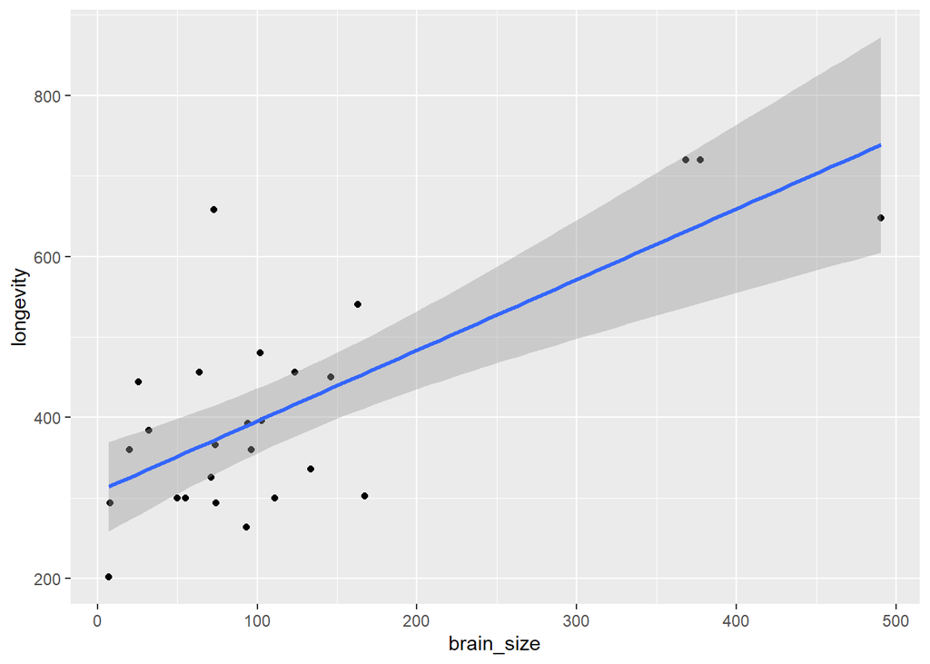

```r
#Therefore, the equation is 307.7522 = y - 0.8789037x

g <- ggplot(data = f, aes(x = brain_size, y = longevity))
g <- g + geom_point()
g <- g + geom_smooth(method = "lm", formula = y ~ x)
g #not able to figure out the geom_text thing yet
```

```r
log_longevity <- log(f$MaxLongevity_m)
log_brain_size <- log(f$Brain_Size_Species_Mean)

beta1 <- cor(log_longevity,log_brain_size)*sd(log_longevity)/sd(log_brain_size)
beta1
```

```
## [1] 0.2028543
```

```r
beta0 <- mean(log_longevity) - beta1 * mean(log_brain_size)
beta0
```

```
## [1] 5.086498
```

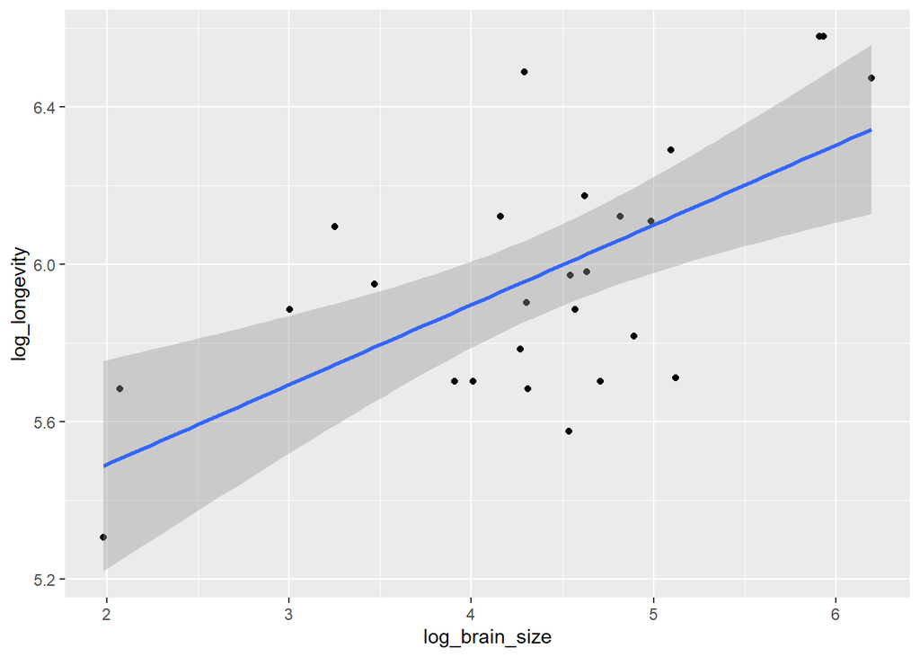

```r
#Therefore, the equation is 5.086498 = y - 0.2028543x

g <- ggplot(data = f, aes(x = log_brain_size, y = log_longevity))
g <- g + geom_point()
g <- g + geom_smooth(method = "lm", formula = y ~ x)
g #not able to figure out the geom_text thing yet
```

### Confidence Intervals:

```r
model <- lm(longevity ~ brain_size, data = f)
beta1_ci <- confint(model, level = 0.90)
beta1_ci
```

```
##                     5 %       95 %
## (Intercept) 260.1112167 355.393214
## brain_size    0.5928154   1.164992
```

```r
summary(model) #based on these results, the values are significant at 0.1 (and even higher)
```

```
##
## Call:
## lm(formula = longevity ~ brain_size, data = f)
##
## Residuals:
##      Min       1Q   Median       3Q      Max
## -152.498  -73.422   -4.425   72.430  285.749
##
## Coefficients:
##             Estimate Std. Error t value Pr(>|t|)
## (Intercept) 307.7522    27.8459  11.052 6.73e-11 ***
## brain_size    0.8789     0.1672   5.256 2.18e-05 ***
## ---
## Signif. codes:  0 '***' 0.001 '**' 0.01 '*' 0.05 '.' 0.1 ' ' 1
##
## Residual standard error: 98.31 on 24 degrees of freedom
## Multiple R-squared:  0.5351, Adjusted R-squared:  0.5158
## F-statistic: 27.63 on 1 and 24 DF,  p-value: 2.176e-05
```

```r
#for the log-regression model
model_log <- lm(log_longevity ~ log_brain_size, data = f)
beta1_log_ci <- confint(model_log, level = 0.90)
beta1_log_ci
```

```
##                      5 %      95 %
## (Intercept)    4.7030309 5.4699646
## log_brain_size 0.1172695 0.2884391
```

```r
summary(model_log) #based on these results, the values are significant at 0.1 (and even higher)
```

```
##
## Call:
## lm(formula = log_longevity ~ log_brain_size, data = f)
##
## Residuals:
##      Min       1Q   Median       3Q      Max
## -0.43044 -0.18029 -0.01211  0.17548  0.53196
##
## Coefficients:
##                Estimate Std. Error t value Pr(>|t|)
## (Intercept)     5.08650    0.22413  22.694  < 2e-16 ***
## log_brain_size  0.20285    0.05002   4.055 0.000458 ***
## ---
## Signif. codes:  0 '***' 0.001 '**' 0.01 '*' 0.05 '.' 0.1 ' ' 1
##
## Residual standard error: 0.2539 on 24 degrees of freedom
## Multiple R-squared:  0.4066, Adjusted R-squared:  0.3819
## F-statistic: 16.44 on 1 and 24 DF,  p-value: 0.0004583
```

I wasn’t sure how to actually do a statistical test to see if beta1 is different from 0, but I used the summary function. I’m not sure if that is correct?

I’m not sure what is meant by ‘interpret the point estimate of the slope of beta1’

# our code looks the same for calculating CI, but our values are slightly different (i think it’s because i didn’t use na.omit initially). I think interpreting the point estimate just means to calculate it? (i also wasn’t sure lmao) - sofia

### Prediction Values:

# Note from sofia: these graphs look great! i don’t know if they’re right because my graphs were absolutely wrong and i kind of threw the towel in for these chunks of code to wait for some advice from peer commentary. in terms of <sub>aesthetics</sub>, if you color by “confidence” and “prediction” it will make a legend for you on the side and then you can later specify colors you want each line to be with scale_color_manual() (i think). alternatively, you can call for a legend later on so it labels lines and doesnt just say color later on.

# you also might want to assign these values as objects to reduce risk of user error.

```r
#For the non-log model, the equation 307.7522 = y - 0.8789037x
lower_longevity <- 260.1112167+0.5928154*(brain_size) #values from calling beta1
lower_longevity #values of longevity based on the lower end of the CI
```

```
##  [1] 289.6808 292.8465 264.4032 303.3452 302.3967 304.2108 303.8788 275.3881
##  [9] 272.0683 550.8338 320.5013 317.3179 315.8181 298.0395 321.1238 315.3616
## [17] 478.4748 359.3604 356.8528 346.7630 483.8279 264.8182 325.8722 333.3239
## [25] 339.1513 279.1524
```

```r
upper_longevity <- 355.393214 + 1.164992*(brain_size)
upper_longevity #values of longevity based on the upper end of the CI
```

```
##  [1] 413.5030 419.7241 363.8278 440.3561 438.4921 442.0570 441.4046 385.4151
##  [9] 378.8911 926.7169 474.0709 467.8149 464.8675 429.9294 475.2942 463.9705
## [17] 784.5180 550.4362 545.5083 525.6801 795.0379 364.6433 484.6258 499.2697
## [25] 510.7216 392.8128
```

```r
#Prediction intervals:
pred_int <- predict(model, interval = "prediction", level = 0.90)
pred_int
```

```
##          fit      lwr      upr
## 6   351.5919 179.0151 524.1688
## 8   356.2853 183.8797 528.6908
## 37  314.1155 139.6963 488.5347
## 43  371.8507 199.9172 543.7841
## 58  370.4444 198.4744 542.4144
## 74  373.1339 201.2328 545.0350
## 75  372.6417 200.7283 544.5551
## 84  330.4016 156.8859 503.9172
## 86  325.4797 151.7076 499.2518
## 97  738.7754 537.2833 940.2674
## 104 397.2861 225.8045 568.7678
## 109 392.5664 221.0311 564.1018
## 120 390.3428 218.7774 561.9082
## 127 363.9845 191.8309 536.1380
## 128 398.2090 226.7363 569.6817
## 137 389.6660 218.0908 561.2412
## 156 631.4964 445.9686 817.0241
## 157 454.8983 282.9638 626.8328
## 158 451.1805 279.3370 623.0240
## 159 436.2216 264.6582 607.7850
## 171 639.4329 452.9011 825.9646
## 186 314.7307 140.3485 489.1129
## 198 405.2490 233.8268 576.6712
## 199 416.2968 244.8923 587.7014
## 203 424.9364 253.4931 596.3798
## 213 335.9826 162.7404 509.2248
```

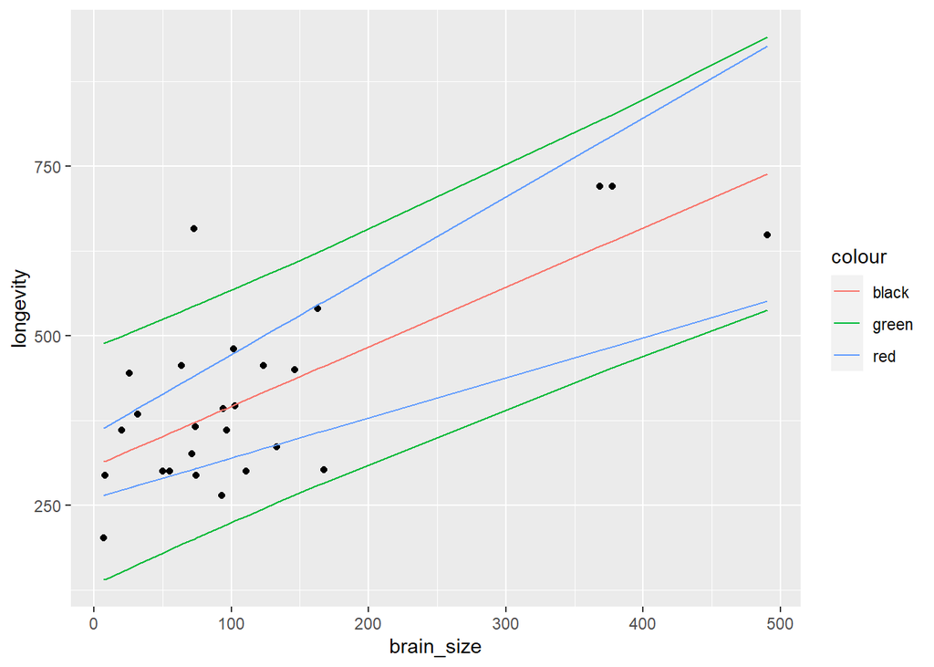

```r
intervals <- as.data.frame(pred_int)
intervals <- cbind(intervals, lower_longevity)
intervals <- cbind(intervals, upper_longevity)
intervals <- cbind(intervals, brain_size)
intervals <- cbind(intervals, longevity)

#Plotting:
g <- ggplot(intervals, aes(x = brain_size, y= longevity))+
  geom_point()+
  geom_line(aes(x = brain_size, y = fit, color = "black"))+
  geom_line(aes(brain_size, lwr, color = "green"))+
  geom_line(aes(brain_size, upr, color = "green"))+
  geom_line(aes(brain_size, lower_longevity, color = "red"))+
  geom_line(aes(brain_size, upper_longevity, color = "red"))

#I need to add a legend but black is the best fit, green is the prediction intervals and red are the CIs

g
```

```r
beta1_log_ci
```

```
##                      5 %      95 %
## (Intercept)    4.7030309 5.4699646
## log_brain_size 0.1172695 0.2884391
```

```r
#For the non-log model, the equation 5.086498 = y - 0.2028543x
log_lower_longevity <- 4.7030309+0.1172695*(log_brain_size) #values from calling beta1_log_ci
log_lower_longevity #values of log_longevity based on the lower end of the CI
```

```
##  [1] 5.161510 5.173437 4.935180 5.206058 5.203457 5.208383 5.207497 5.084064
##  [9] 5.055332 5.429544 5.245250 5.238899 5.235783 5.190704 5.246452 5.234818
## [17] 5.395980 5.303510 5.300509 5.287592 5.398820 4.946003 5.255241 5.267829
## [25] 5.276810 5.109895
```

```r
log_upper_longevity <- 5.4699646 + 0.2884391*(log_brain_size)
log_upper_longevity #values of log_longevity based on the upper end of the CI
```

```
##  [1] 6.597652 6.626988 6.040965 6.707224 6.700826 6.712941 6.710762 6.407164
##  [9] 6.336492 7.256915 6.803620 6.787999 6.780336 6.669459 6.806578 6.777963
## [17] 7.174361 6.946919 6.939537 6.907767 7.181347 6.067585 6.828195 6.859157
## [25] 6.881247 6.470698
```

```r
#Prediction intervals:
pred_int_log <- predict(model_log, interval = "prediction", level = 0.90)
pred_int_log
```

```
##          fit      lwr      upr
## 6   5.879581 5.435127 6.324035
## 8   5.900212 5.456443 6.343982
## 37  5.488072 5.000426 5.975719
## 43  5.956641 5.513874 6.399408
## 58  5.952141 5.509341 6.394941
## 74  5.960662 5.517918 6.403406
## 75  5.959129 5.516377 6.401881
## 84  5.745614 5.292652 6.198576
## 86  5.695912 5.238056 6.153767
## 97  6.343229 5.873721 6.812737
## 104 6.024435 5.581181 6.467688
## 109 6.013449 5.570400 6.456498
## 120 6.008060 5.565093 6.451027
## 127 5.930082 5.487002 6.373161
## 128 6.026515 5.583217 6.469812
## 137 6.006391 5.563447 6.449334
## 156 6.285171 5.823241 6.747100
## 157 6.125214 5.677846 6.572583
## 158 6.120023 5.672965 6.567082
## 159 6.097680 5.651834 6.543525
## 171 6.290083 5.827558 6.752609
## 186 5.506794 5.022406 5.991182
## 198 6.041718 5.598046 6.485391
## 199 6.063493 5.619123 6.507863
## 203 6.079029 5.634045 6.524012
## 213 5.790296 5.340944 6.239649
```

```r
intervals_log <- as.data.frame(pred_int_log)
intervals_log <- cbind(intervals_log, log_lower_longevity)
intervals_log <- cbind(intervals_log, log_upper_longevity)
intervals_log <- cbind(intervals_log, log_brain_size)
intervals_log <- cbind(intervals_log, log_longevity)

#Plotting:
g <- ggplot(intervals_log, aes(x = log_brain_size, y= log_longevity))+
  geom_point()+
  geom_line(aes(x = log_brain_size, y = fit, color = "black"))+
  geom_line(aes(log_brain_size, lwr, color = "green"))+
  geom_line(aes(log_brain_size, upr, color = "green"))+
  geom_line(aes(log_brain_size, log_lower_longevity, color = "red"))+
  geom_line(aes(log_brain_size, log_upper_longevity, color = "red"))

#I need to add a legend but black is the best fit, green is the prediction intervals and red are the CIs
```

### Point Estimate for brain size = 800 gms

#Note from sofia: # i believe we calculated this the same way. we have slightly different values but, again, i think this is a me error.

```r
point_estimate <- 307.7522 + 0.8789037*800
point_estimate #1010.875 months
```

```
## [1] 1010.875
```

```r
log_point_estimate <- 5.086498 + 0.2028543*800 #I'm not sure what to do with this.
log_point_estimate
```

```
## [1] 167.3699
```

Overall, I don’t these are bad models to predict the longevity accurately. Brain_size is considered a constant which is used to predict longevity, which I don’t think is a bad assumption to make. I do think that the log transformed model is better as it evens out the data a bit (takes care of the extreme values).

## Challenges I faced:

1. Making the function made me cry. I kept questioning if I knew what I was doing. Probably not.
2. The function is so long and inefficient. I didn’t have time to fix that. And I’m not sure if I’ve made the loops correctly to begin with.
3. The geom_text function is so confusing. I still can’t figure it out.

# literally same. I’m so sorry i couldn’t give more feedback other than just comparison for this assignment! I’m not confident in my code that my code that runs :’) but overall great job! your graphs look great and your code is super clean and you left good comments.